# Data Analysis and Prediction for Life Expectancy

Group 106: Artsiom Strok, Lin Jiang, Mayank Chhablani

July 15, 2019

## Introduction

### Team information

| Name | NetID | Email |
| --- | --- | --- |
| Artsiom Strok | astrok2 | astrok2@illinois.edu |
| Lin Jiang | linj3 | linj3@illinois.edu |
| Mayank Chhablani | mchhab2 | mchhab2@illinois.edu |

### Description of the dataset

Life expectancy has increased dramatically over the last few centuries. Since 1900 the global average life expectancy has more than doubled and there has been a huge development in health sector in the past 15 years resulting in improvement of human mortality rates especially in the developing nations in comparison to the past 30 years. Therefore, in this project, only data from year 2000-2015 is considered for exploration and analysis.

The description of each variable for this dataset is listed below:

**Numerical Response**

- `Life expectancy`: Life Expectancy in age

**Numerical Predictors**

- `Year`: Year
- `Adult Mortality`: Adult Mortality Rates of both sexes (probability of dying between 15 and 60 years per 1000 population)
- `infant`: deathsNumber of Infant Deaths per 1000 population
- `Alcohol`: Alcohol, recorded per capita (15+) consumption (in litres of pure alcohol)
- `percentage expenditure`: Expenditure on health as a percentage of Gross Domestic Product per capita(%)
- `Hepatitis B`: Hepatitis B (HepB) immunization coverage among 1-year-olds (%)
- `Measles`: Measles - number of reported cases per 1000 population
- `BMI`: Average Body Mass Index of entire population
- `under-five deaths`: Number of under-five deaths per 1000 population
- `Polio`: Polio (Pol3) immunization coverage among 1-year-olds (%)
- `Total expenditure`: General government expenditure on health as a percentage of total government expenditure (%)
- `Diphtheria`: Diphtheria tetanus toxoid and pertussis (DTP3) immunization coverage among 1-year-olds (%)
- `HIV/AIDS`: Deaths per 1 000 live births HIV/AIDS (0-4 years)
- `GDP`: Gross Domestic Product per capita (in USD)
- `Population`: Population of the country
- `thinness 1-19 years`: Prevalence of thinness among children and adolescents for Age 10 to 19 (% )
- `thinness 5-9 years`: Prevalence of thinness among children for Age 5 to 9(%)
- `Income composition of resources`: Human Development Index in terms of income composition of resources (index ranging from 0 to 1)
- `Schooling`: Number of years of Schooling(years)

**Categotical Predictors**

- `Country`: Country
- `Status`: Developed or Developing status

### Background information

The GHO data repository is WHO’s gateway to health-related statistics which provides access to a variety of indicators on priority health topics including mortality and burden of diseases, environmental health, violence and injuries etc. (http://apps.who.int/gho/data/node.resources).

The economic data such as GDP is collected from the National Accounts Main Aggregates Database under United Nations which collects and disseminates economic statistics from countries worldwide (https://unstats.un.org/unsd/snaama/Index).

By combining the data from these two databases and exploring the interactions between the variables such as immunization, moratlity, education and economic factors, we expect to build a robust multiple linear regression model to predict the life expectancy more accurately.

### Statement of interest

- Identify the major factors that affect the life expectancy
- Explore the interactions between different variables, such as lower life expectancy vs healthcare expenditure
- Discover the corelation between different factors
- Build model to predict life expectancy for a certain country
- Based on life expectancy data to classify the status of a country (developing or developed)

### Samples of the data

```r
library(knitr)
data = read.csv("Life Expectancy Data.csv")
kable(t(data[sample(nrow(data), 5), ]))
```

|  | 985 | 1975 | 41 | 611 | 1261 |
| --- | --- | --- | --- | --- | --- |
| Country | Georgia | Panama | Algeria | Congo | Ireland |
| Year | 2009 | 2000 | 2007 | 2013 | 2005 |
| Status | Developing | Developing | Developing | Developing | Developed |
| Life.expectancy | 73.2 | 75.7 | 73.8 | 63.9 | 78.7 |
| Adult.Mortality | 133 | 121 | 129 | 274 | 78 |
| infant.deaths | 1 | 2 | 20 | 7 | 0 |
| Alcohol | 6.66 | 5.58 | 0.44 | 0.01 | 13.31 |
| percentage.expenditure | 18.531 | 9.871 | 320.324 | 0.000 | 973.681 |
| Hepatitis.B | 54 | NA | 9 | 85 | NA |
| Measles | 23 | 0 | 0 | 124 | 95 |
| BMI | 51.3 | 45.9 | 5.8 | 26.2 | 55.1 |
| under.five.deaths | 1 | 2 | 23 | 10 | 0 |
| Polio | 93 | 99 | 95 | 85 | 9 |
| Total.expenditure | 1.19 | 7.76 | 3.82 | 5.90 | 7.27 |
| Diphtheria | 88 | 98 | 95 | 85 | 9 |
| HIV.AIDS | 0.1 | 0.2 | 0.1 | 3.0 | 0.1 |
| GDP | 276.6 | 46.3 | 3935.2 | NA | 5886.8 |
| Population | 3978 | 33347 | 34376 | NA | 4159914 |
| thinness..1.19.years | 2.6 | 2.4 | 6.0 | 7.7 | 0.3 |
| thinness.5.9.years | 2.8 | 2.3 | 5.9 | 7.4 | 0.2 |
| Income.composition.of.resources | 0.734 | 0.716 | 0.690 | 0.576 | 0.889 |
| Schooling | 12.8 | 12.1 | 12.3 | 11.1 | 17.5 |

## Model Building

First check the collinearity issue in our dataset

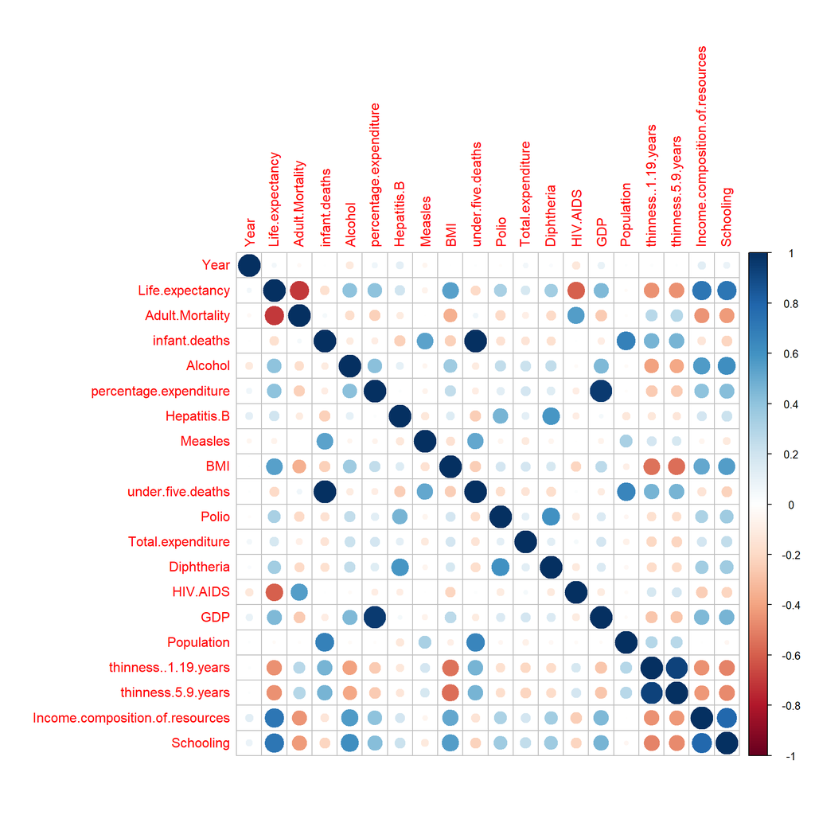

```r
#View(data[-1])
#Data must be numeric, so exclude Country and Status
data=na.omit(data)
corrplot::corrplot(cor(data[-c(1,3)]))
```

```r
#Remove Country from the dataset
data = data[-1]
```

From the figure, it is quite evident that following predictors have high correlation between them: (1) `infant.deaths` and `under.five.deaths` (2) `GDP` vs `percentage.expenditure`. Going forward, we will keep this predictors on watch to assess any collinearity issues.

#### Spit dataset into train-test

```r
group_num=106
set.seed(106)
split_percent=0.8
total_num_samples=nrow(data)
train_split = floor(split_percent * total_num_samples)
train_idx = sample(total_num_samples, train_split)
train_dataset = data[train_idx, ]
test_dataset = data[-train_idx, ]
```

Helper Functions for evaluation metrics

```r
library(lmtest)
#RMSE
calculate_rmse <- function(actual, predicted){
  mean((actual - predicted) ^ 2)
}

#BP-Test: Equal variance test
calculate_bptest <- function(model){
  bptest(model)$"p.value"
}

#Shaipro-Test: Normality test
calculate_shapiro_test <- function(model){
  shapiro.test(resid(model))$"p.value"
}

#Adjusted R_squared test
calculate_adj_r2 <- function(model){
  summary(model)$"adj.r.squared"
}

#LOOCV
calc_loocv_rmse = function(model) {
  sqrt(mean((resid(model) / (1 - hatvalues(model))) ^ 2))
}

#Get metrics in table
show_metrics <- function(model){
  data.frame(bptest=toString(unname(calculate_bptest(model))),
                                 shapiro_test=toString(unname(calculate_shapiro_test(model))),
                                 adj_r2=toString(calculate_adj_r2(model)),
                                 LOOCV=toString(calc_loocv_rmse(model)),
                                 RMSE=toString(calculate_rmse(test_dataset$Life.expectancy, predict(model, test_dataset))))
}
```

`Steps to generate best model:`

We will start with simple additive model and then use AIC/ BIC to weed out unnecessary predictors. We then, may try out interactions and see if that improves our model and later, we may use response or, predictor transformations to improve our selected model.

`Additve Model with all predictors`

```r
model_additive_all=lm(Life.expectancy ~ . , data=train_dataset)
summary(model_additive_all)
```

```
##
## Call:
## lm(formula = Life.expectancy ~ ., data = train_dataset)
##
## Residuals:
##     Min      1Q  Median      3Q     Max
## -16.720  -2.124  -0.007   2.135  11.922
##
## Coefficients:
##                                  Estimate Std. Error t value Pr(>|t|)
## (Intercept)                      2.95e+02   5.10e+01    5.78  9.2e-09 ***
## Year                            -1.20e-01   2.55e-02   -4.72  2.6e-06 ***
## StatusDeveloping                -9.57e-01   3.66e-01   -2.62  0.00902 **
## Adult.Mortality                 -1.56e-02   1.04e-03  -15.02  < 2e-16 ***
## infant.deaths                    9.23e-02   1.15e-02    8.04  2.0e-15 ***
## Alcohol                         -1.22e-01   3.71e-02   -3.30  0.00098 ***
## percentage.expenditure           3.31e-04   2.00e-04    1.65  0.09846 .
## Hepatitis.B                     -1.87e-03   4.87e-03   -0.38  0.70069
## Measles                         -1.22e-05   1.16e-05   -1.06  0.28989
## BMI                              3.07e-02   6.50e-03    4.72  2.7e-06 ***
## under.five.deaths               -6.87e-02   8.24e-03   -8.33  < 2e-16 ***
## Polio                            4.19e-03   5.81e-03    0.72  0.47103
## Total.expenditure                5.98e-02   4.50e-02    1.33  0.18405
## Diphtheria                       1.42e-02   6.56e-03    2.17  0.03019 *
## HIV.AIDS                        -4.31e-01   1.97e-02  -21.87  < 2e-16 ***
## GDP                              1.10e-05   3.17e-05    0.35  0.72835
## Population                      -1.28e-09   1.86e-09   -0.69  0.49007
## thinness..1.19.years             2.94e-02   5.75e-02    0.51  0.60998
## thinness.5.9.years              -9.55e-02   5.64e-02   -1.69  0.09068 .
## Income.composition.of.resources  1.12e+01   9.62e-01   11.63  < 2e-16 ***
## Schooling                        8.88e-01   6.58e-02   13.50  < 2e-16 ***
## ---
## Signif. codes:  0 '***' 0.001 '**' 0.01 '*' 0.05 '.' 0.1 ' ' 1
##
## Residual standard error: 3.49 on 1298 degrees of freedom
## Multiple R-squared:  0.844,  Adjusted R-squared:  0.841
## F-statistic:  350 on 20 and 1298 DF,  p-value: <2e-16
```

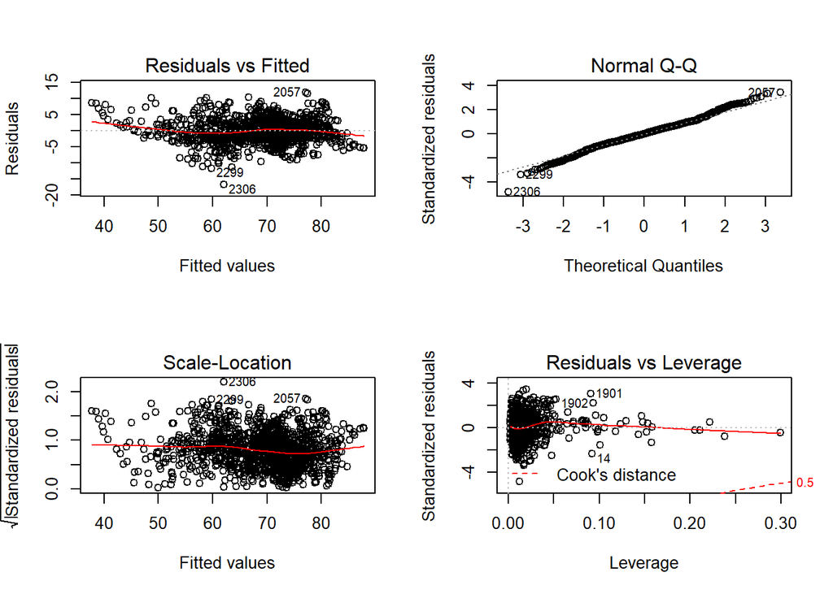

```r
par(mfrow=c(2,2))
plot(model_additive_all)
```

So, looking at `Residual vs Fitted plot` that we may have issue of linearity and equal-variance. Similary, we need to check for `normality assumption` as dictated by `Normal Q-Q plot`

Let’s check for `Homoscedasticity`and `Normality` assumptions.

```r
show_metrics(model_additive_all)
```

```
##                 bptest         shapiro_test            adj_r2            LOOCV
## 1 2.17343275886271e-20 4.81616062881183e-07 0.841351899438058 3.52408733205924
##               RMSE
## 1 14.7065151051994
```

So, from above data it looks liek although `Adjusted R^2` and `RMSE` is better, but, we `REJECT` both `Homoscedasticity`and `Normality` assumptions. Also, from summary of model it seems there is need to prune out some predictors.

Let’s apply AIC and BIC to see if we can improve our model

```r
model_additive_all_aic=step(model_additive_all, trace=0)
summary(model_additive_all_aic)
```

```
##
## Call:
## lm(formula = Life.expectancy ~ Year + Status + Adult.Mortality +
##     infant.deaths + Alcohol + percentage.expenditure + BMI +
##     under.five.deaths + Diphtheria + HIV.AIDS + thinness.5.9.years +
##     Income.composition.of.resources + Schooling, data = train_dataset)
##
## Residuals:
##     Min      1Q  Median      3Q     Max
## -16.961  -2.137   0.017   2.141  12.056
##
## Coefficients:
##                                  Estimate Std. Error t value Pr(>|t|)
## (Intercept)                      2.90e+02   4.98e+01    5.82  7.2e-09 ***
## Year                            -1.18e-01   2.49e-02   -4.73  2.5e-06 ***
## StatusDeveloping                -1.00e+00   3.63e-01   -2.77  0.00567 **
## Adult.Mortality                 -1.57e-02   1.04e-03  -15.17  < 2e-16 ***
## infant.deaths                    8.73e-02   1.06e-02    8.26  3.6e-16 ***
## Alcohol                         -1.22e-01   3.68e-02   -3.30  0.00099 ***
## percentage.expenditure           4.00e-04   6.43e-05    6.22  6.8e-10 ***
## BMI                              3.13e-02   6.44e-03    4.85  1.4e-06 ***
## under.five.deaths               -6.58e-02   7.82e-03   -8.41  < 2e-16 ***
## Diphtheria                       1.55e-02   4.93e-03    3.15  0.00168 **
## HIV.AIDS                        -4.27e-01   1.95e-02  -21.91  < 2e-16 ***
## thinness.5.9.years              -7.05e-02   2.85e-02   -2.48  0.01335 *
## Income.composition.of.resources  1.12e+01   9.56e-01   11.67  < 2e-16 ***
## Schooling                        8.97e-01   6.49e-02   13.83  < 2e-16 ***
## ---
## Signif. codes:  0 '***' 0.001 '**' 0.01 '*' 0.05 '.' 0.1 ' ' 1
##
## Residual standard error: 3.49 on 1305 degrees of freedom
## Multiple R-squared:  0.843,  Adjusted R-squared:  0.842
## F-statistic:  540 on 13 and 1305 DF,  p-value: <2e-16
```

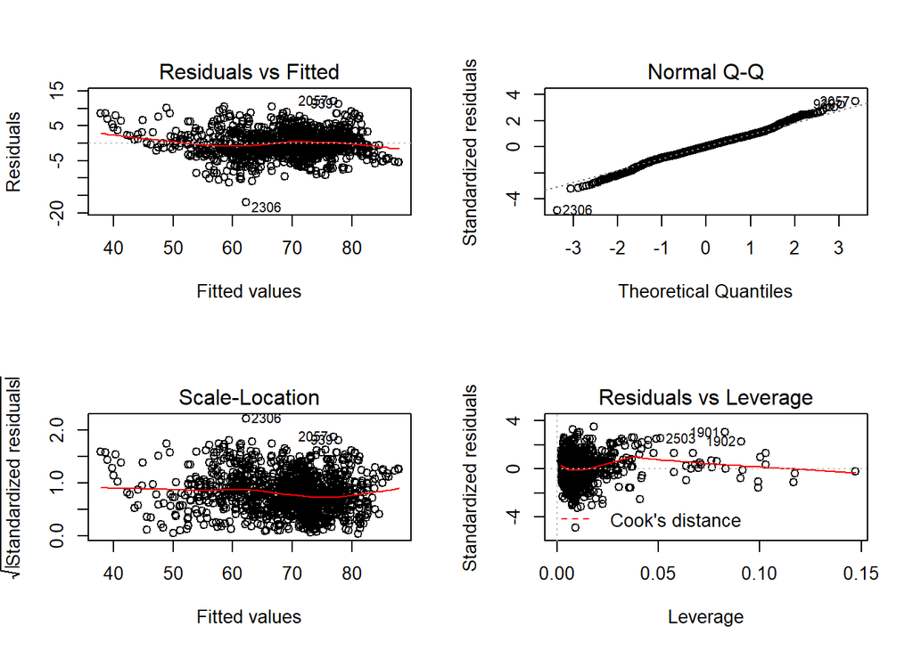

```r
par(mfrow=c(2,2))
plot(model_additive_all_aic)
```

So, looking at AIC model, we can see that `GDP`vs `percentage.expenditure` collinearity issue has been removed by AIC. Also, some of the non-significant predictors are also removed.

```r
show_metrics(model_additive_all_aic)
```

```
##               bptest         shapiro_test            adj_r2            LOOCV
## 1 3.090041736981e-22 5.23220401607279e-07 0.841662026790237 3.51460850200996
##               RMSE
## 1 14.8195081521065
```

Apart from reduction in predictors, there isn’t a significant improvement. Let’s try out BIC:

```r
model_additive_all_bic=step(model_additive_all, trace=0, k = log(nrow(train_dataset)))
summary(model_additive_all_bic)
```

```
##
## Call:
## lm(formula = Life.expectancy ~ Year + Status + Adult.Mortality +
##     infant.deaths + Alcohol + percentage.expenditure + BMI +
##     under.five.deaths + Diphtheria + HIV.AIDS + Income.composition.of.resources +
##     Schooling, data = train_dataset)
##
## Residuals:
##     Min      1Q  Median      3Q     Max
## -17.014  -2.092   0.017   2.114  12.398
##
## Coefficients:
##                                  Estimate Std. Error t value Pr(>|t|)
## (Intercept)                      2.92e+02   4.99e+01    5.86  5.9e-09 ***
## Year                            -1.19e-01   2.49e-02   -4.78  2.0e-06 ***
## StatusDeveloping                -1.00e+00   3.63e-01   -2.76   0.0058 **
## Adult.Mortality                 -1.58e-02   1.04e-03  -15.29  < 2e-16 ***
## infant.deaths                    8.48e-02   1.05e-02    8.04  1.9e-15 ***
## Alcohol                         -1.10e-01   3.66e-02   -3.00   0.0028 **
## percentage.expenditure           4.05e-04   6.44e-05    6.29  4.3e-10 ***
## BMI                              3.68e-02   6.06e-03    6.08  1.6e-09 ***
## under.five.deaths               -6.46e-02   7.82e-03   -8.26  3.5e-16 ***
## Diphtheria                       1.55e-02   4.94e-03    3.13   0.0018 **
## HIV.AIDS                        -4.31e-01   1.95e-02  -22.11  < 2e-16 ***
## Income.composition.of.resources  1.13e+01   9.56e-01   11.80  < 2e-16 ***
## Schooling                        9.00e-01   6.50e-02   13.85  < 2e-16 ***
## ---
## Signif. codes:  0 '***' 0.001 '**' 0.01 '*' 0.05 '.' 0.1 ' ' 1
##
## Residual standard error: 3.49 on 1306 degrees of freedom
## Multiple R-squared:  0.842,  Adjusted R-squared:  0.841
## F-statistic:  582 on 12 and 1306 DF,  p-value: <2e-16
```

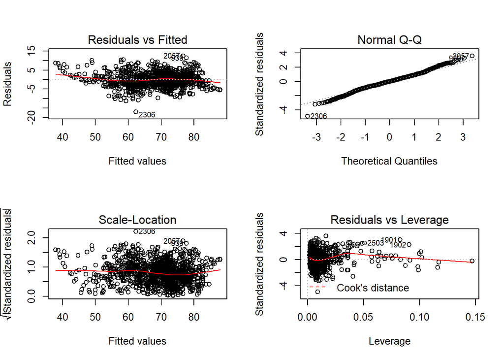

```r
par(mfrow=c(2,2))
plot(model_additive_all_bic)
```

```r
show_metrics(model_additive_all_bic)
```

```
##                 bptest         shapiro_test           adj_r2            LOOCV
## 1 1.14282473257436e-22 1.33088130547613e-06 0.84103907220831 3.52013788768898
##               RMSE
## 1 14.7556455485935
```

So, BIC and AIC resutls are almost same and so does the evaluatin metric but, we saw two improvements: (1) `Reduction in number of predictors` (2) `Reduction in influential points` as per the `Residual vs Leverage` graph.

Hence, let’s select AIC model and try interactions. The BIC is little aggressive in removing predictors so, we are selecting AIC additive model.

Also, let’s check for variance-inflation-factor

```r
vif_aic_all_model=car::vif(model_additive_all_aic)
vif_aic_all_model[vif_aic_all_model>5]
```

```
##     infant.deaths under.five.deaths
##             180.5             181.3
```

As evident from above `VIF` computation, `infant.deaths` and `under.five.deaths` in the model are causing `collinearity issue`. This same issue we found during our correlation plot. Let’s try to improve the model and remove issues which are violating linearity assumptions.

`Applying Two-Way Interaction`:

```r
model_interaction_all=lm(Life.expectancy ~ .^2, data=train_dataset)
```

AIC Interaction Model:

```r
model_interaction_all_aic=step(model_interaction_all, trace=0)
summary(model_interaction_all_aic)
```

```
##
## Call:
## lm(formula = Life.expectancy ~ Year + Status + Adult.Mortality +
##     infant.deaths + Alcohol + percentage.expenditure + Hepatitis.B +
##     Measles + BMI + under.five.deaths + Polio + Total.expenditure +
##     Diphtheria + HIV.AIDS + GDP + Population + thinness..1.19.years +
##     thinness.5.9.years + Income.composition.of.resources + Schooling +
##     Year:Adult.Mortality + Year:infant.deaths + Year:Alcohol +
##     Year:percentage.expenditure + Year:under.five.deaths + Year:Total.expenditure +
##     Year:HIV.AIDS + Year:GDP + Year:Income.composition.of.resources +
##     Year:Schooling + Status:Adult.Mortality + Status:infant.deaths +
##     Status:percentage.expenditure + Status:Hepatitis.B + Status:BMI +
##     Status:under.five.deaths + Status:Total.expenditure + Status:Diphtheria +
##     Status:GDP + Status:thinness.5.9.years + Status:Income.composition.of.resources +
##     Status:Schooling + Adult.Mortality:percentage.expenditure +
##     Adult.Mortality:BMI + Adult.Mortality:under.five.deaths +
##     Adult.Mortality:Total.expenditure + Adult.Mortality:HIV.AIDS +
##     Adult.Mortality:GDP + Adult.Mortality:Population + Adult.Mortality:thinness..1.19.years +
##     Adult.Mortality:thinness.5.9.years + Adult.Mortality:Income.composition.of.resources +
##     Adult.Mortality:Schooling + infant.deaths:percentage.expenditure +
##     infant.deaths:Hepatitis.B + infant.deaths:Measles + infant.deaths:BMI +
##     infant.deaths:Diphtheria + infant.deaths:HIV.AIDS + infant.deaths:GDP +
##     infant.deaths:Population + infant.deaths:thinness..1.19.years +
##     infant.deaths:Schooling + Alcohol:Hepatitis.B + Alcohol:Measles +
##     Alcohol:Total.expenditure + Alcohol:Diphtheria + Alcohol:HIV.AIDS +
##     Alcohol:Population + Alcohol:thinness..1.19.years + Alcohol:Income.composition.of.resources +
##     Alcohol:Schooling + percentage.expenditure:Diphtheria + percentage.expenditure:GDP +
##     percentage.expenditure:thinness..1.19.years + percentage.expenditure:thinness.5.9.years +
##     percentage.expenditure:Income.composition.of.resources +
##     percentage.expenditure:Schooling + Hepatitis.B:Total.expenditure +
##     Hepatitis.B:Diphtheria + Hepatitis.B:thinness..1.19.years +
##     Measles:under.five.deaths + Measles:Polio + Measles:Population +
##     BMI:under.five.deaths + BMI:Total.expenditure + BMI:HIV.AIDS +
##     BMI:thinness..1.19.years + BMI:Income.composition.of.resources +
##     BMI:Schooling + under.five.deaths:Polio + under.five.deaths:Diphtheria +
##     under.five.deaths:GDP + under.five.deaths:Population + under.five.deaths:thinness..1.19.years +
##     under.five.deaths:thinness.5.9.years + under.five.deaths:Income.composition.of.resources +
##     under.five.deaths:Schooling + Polio:Total.expenditure + Polio:GDP +
##     Polio:Income.composition.of.resources + Total.expenditure:Diphtheria +
##     Total.expenditure:HIV.AIDS + Total.expenditure:GDP + Total.expenditure:Population +
```

[output cut: 243 more lines]

```
## Diphtheria:Schooling                                     -4.34  1.5e-05 ***
## HIV.AIDS:Population                                      -1.39  0.16568
## GDP:thinness..1.19.years                                 -2.46  0.01418 *
## GDP:thinness.5.9.years                                    2.89  0.00398 **
## GDP:Schooling                                             4.05  5.5e-05 ***
## Population:thinness..1.19.years                           1.40  0.16149
## thinness..1.19.years:thinness.5.9.years                   4.20  2.9e-05 ***
## thinness.5.9.years:Income.composition.of.resources       -1.79  0.07341 .
## thinness.5.9.years:Schooling                              4.01  6.4e-05 ***
## ---
## Signif. codes:  0 '***' 0.001 '**' 0.01 '*' 0.05 '.' 0.1 ' ' 1
##
## Residual standard error: 2.58 on 1200 degrees of freedom
## Multiple R-squared:  0.921,  Adjusted R-squared:  0.913
## F-statistic:  118 on 118 and 1200 DF,  p-value: <2e-16
```

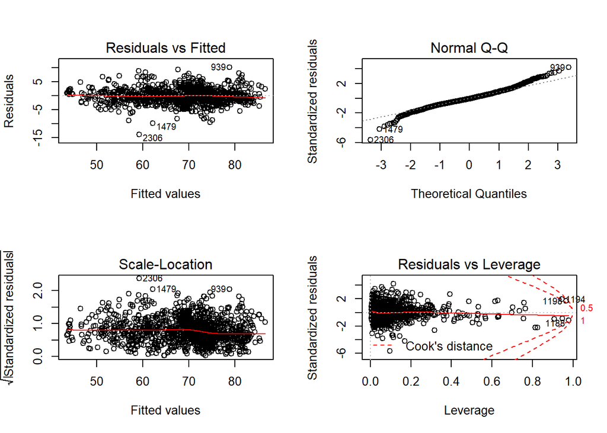

```r
par(mfrow=c(2,2))
plot(model_interaction_all_aic)
```

```r
show_metrics(model_interaction_all_aic)
```

```
##                bptest         shapiro_test            adj_r2           LOOCV
## 1 0.00245155177968334 2.99483908292635e-13 0.913077354594192 2.9795101906262
##               RMSE
## 1 12.3564574671017
```

```r
vif_interaction_model=car::vif(model_interaction_all_aic)
vif_interaction_model[vif_interaction_model>5]
```

```
##                                                   Year
##                                              6.931e+01
##                                                 Status
##                                              1.385e+03
##                                        Adult.Mortality
##                                              6.674e+05
##                                          infant.deaths
##                                              2.646e+08
##                                                Alcohol
##                                              5.934e+05
##                                 percentage.expenditure
##                                              8.127e+06
##                                            Hepatitis.B
##                                              5.755e+01
##                                                Measles
##                                              1.052e+02
##                                                    BMI
##                                              1.880e+02
##                                      under.five.deaths
##                                              2.895e+08
##                                                  Polio
##                                              3.375e+01
##                                      Total.expenditure
##                                              4.111e+05
##                                             Diphtheria
##                                              2.694e+02
##                                               HIV.AIDS
##                                              9.398e+05
##                                                    GDP
##                                              7.923e+06
##                                             Population
##                                              7.425e+02
##                                   thinness..1.19.years
##                                              7.974e+01
##                                     thinness.5.9.years
##                                              7.007e+02
##                        Income.composition.of.resources
##                                              1.486e+06
##                                              Schooling
##                                              1.359e+06
```

[output cut: 179 more lines]

```
##                                              1.384e+02
##                               GDP:thinness..1.19.years
##                                              5.134e+02
##                                 GDP:thinness.5.9.years
##                                              5.288e+02
##                                          GDP:Schooling
##                                              2.073e+03
##                        Population:thinness..1.19.years
##                                              1.520e+02
##                thinness..1.19.years:thinness.5.9.years
##                                              3.937e+01
##     thinness.5.9.years:Income.composition.of.resources
##                                              3.637e+01
##                           thinness.5.9.years:Schooling
##                                              1.090e+02
```

This interaction model is getting overly complicated. Let’s inspect pairs scatter plot.

```r
pairs(data.frame(data$Life.expectancy, data$Year, data$Status, data$Adult.Mortality, data$infant.deaths, data$Alcohol, data$percentage.expenditure, data$BMI, data$under.five.deaths, data$Polio, data$Total.expenditure, data$HIV.AIDS, data$thinness.5.9.years, data$Income.composition.of.resources, data$Schooling))
```

[figure not shown]

Based on this cross-predictor plots, we confirm that (a) `HIV.AIDS` has non-linear relationship with `Life.expectancy' and, (B)`HIV.AIDS`and`Adult.Mortality`are also interacting non-linearly. Also, we may condsider removing`Year` because it may divert model in different direction because of its chaotic relationship with the response.

Check for impact of high VIF predictors.

```r
model_selected_wo_underfive=lm(Life.expectancy ~ Year + Status + Adult.Mortality + infant.deaths + Alcohol + percentage.expenditure + BMI + Polio + Total.expenditure + HIV.AIDS + thinness.5.9.years + Income.composition.of.resources + Schooling, data=train_dataset)

model_selected_wo_infant.deaths=lm(Life.expectancy ~ Year + Status + Adult.Mortality + under.five.deaths + Alcohol + percentage.expenditure + BMI + Polio + Total.expenditure + HIV.AIDS + thinness.5.9.years + Income.composition.of.resources + Schooling, data=train_dataset)

model_selected_underfive=lm(under.five.deaths ~ Year + Status + Adult.Mortality + infant.deaths + Alcohol + percentage.expenditure + BMI  + Polio + Total.expenditure + HIV.AIDS + thinness.5.9.years + Income.composition.of.resources + Schooling, data=train_dataset)

model_selected_infant.deaths=lm(infant.deaths ~ Year + Status + Adult.Mortality + under.five.deaths + Alcohol + percentage.expenditure + BMI + Polio + Total.expenditure + HIV.AIDS + thinness.5.9.years + Income.composition.of.resources + Schooling, data=train_dataset)

cor(resid(model_selected_underfive), resid(model_selected_wo_underfive))
```

```
## [1] -0.2342
```

```r
cor(resid(model_selected_infant.deaths), resid(model_selected_wo_infant.deaths))
```

```
## [1] 0.23
```

Based on this we can get rid of `under.five.deaths`

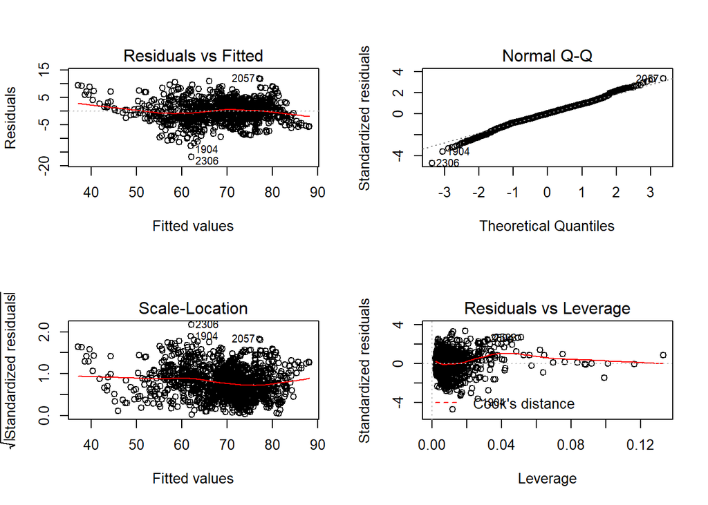

```r
model_selected=lm(Life.expectancy ~ Year + Status + Adult.Mortality + infant.deaths + Alcohol + percentage.expenditure + BMI   + Polio + Total.expenditure + HIV.AIDS + thinness.5.9.years + Income.composition.of.resources + Schooling , data=train_dataset)
par(mfrow=c(2,2))
plot(model_selected)
```

```r
show_metrics(model_selected)
```

```
##                bptest         shapiro_test            adj_r2            LOOCV
## 1 1.5248068200164e-28 1.03459629540506e-06 0.832157276259373 3.61917123378019
##               RMSE
## 1 15.0917759071389
```

```r
car::vif(model_selected)
```

```
##                            Year                          Status
##                           1.117                           1.834
##                 Adult.Mortality                   infant.deaths
##                           1.834                           1.335
##                         Alcohol          percentage.expenditure
##                           2.267                           1.385
##                             BMI                           Polio
##                           1.781                           1.183
##               Total.expenditure                        HIV.AIDS
##                           1.125                           1.563
##              thinness.5.9.years Income.composition.of.resources
##                           1.920                           3.152
##                       Schooling
##                           3.586
```

Looks like none of our predictor is causing inflation in variance. Let’s consider interaction of these predictors.

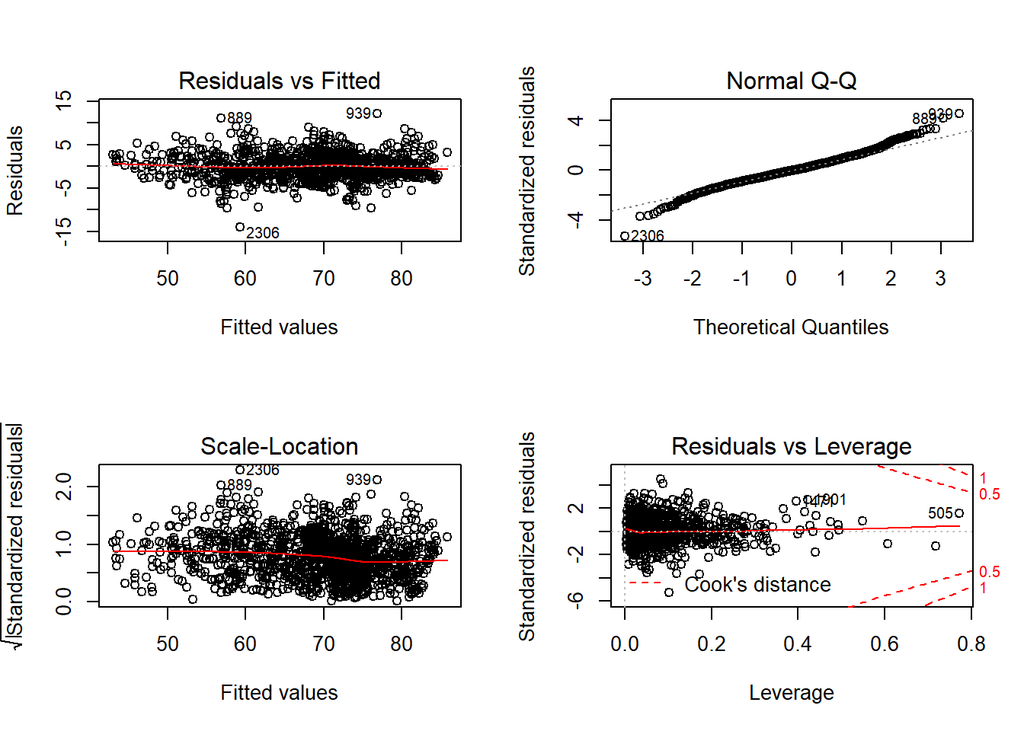

```r
model_selected_interactions=lm(Life.expectancy ~ (Year + Status + Adult.Mortality + infant.deaths + Alcohol + percentage.expenditure + BMI   + Polio + Total.expenditure + HIV.AIDS + thinness.5.9.years + Income.composition.of.resources + Schooling)^2 , data=train_dataset)
par(mfrow=c(2,2))
plot(model_selected_interactions)
```

```r
show_metrics(model_selected_interactions)
```

```
##                 bptest         shapiro_test            adj_r2            LOOCV
## 1 2.85762343521289e-09 2.16809659111906e-10 0.897174280422837 2.97097656907452
##               RMSE
## 1 10.6488235527573
```

```r
model_selected_interactions_aic=step(model_selected_interactions, trace=0)
summary(model_selected_interactions_aic)
```

```
##
## Call:
## lm(formula = Life.expectancy ~ Year + Status + Adult.Mortality +
##     infant.deaths + Alcohol + percentage.expenditure + BMI +
##     Polio + Total.expenditure + HIV.AIDS + thinness.5.9.years +
##     Income.composition.of.resources + Schooling + Year:infant.deaths +
##     Year:Alcohol + Year:percentage.expenditure + Year:Polio +
##     Year:Total.expenditure + Year:HIV.AIDS + Year:Income.composition.of.resources +
##     Year:Schooling + Status:Adult.Mortality + Status:infant.deaths +
##     Status:Alcohol + Status:percentage.expenditure + Status:Total.expenditure +
##     Status:thinness.5.9.years + Status:Income.composition.of.resources +
##     Status:Schooling + Adult.Mortality:infant.deaths + Adult.Mortality:BMI +
##     Adult.Mortality:Total.expenditure + Adult.Mortality:HIV.AIDS +
##     Adult.Mortality:thinness.5.9.years + Adult.Mortality:Income.composition.of.resources +
##     Adult.Mortality:Schooling + infant.deaths:percentage.expenditure +
##     infant.deaths:BMI + infant.deaths:Polio + infant.deaths:Total.expenditure +
##     infant.deaths:Income.composition.of.resources + infant.deaths:Schooling +
##     Alcohol:Total.expenditure + Alcohol:HIV.AIDS + Alcohol:thinness.5.9.years +
##     Alcohol:Income.composition.of.resources + percentage.expenditure:BMI +
##     percentage.expenditure:Total.expenditure + percentage.expenditure:Income.composition.of.resources +
##     percentage.expenditure:Schooling + BMI:Total.expenditure +
##     BMI:HIV.AIDS + BMI:thinness.5.9.years + BMI:Income.composition.of.resources +
##     BMI:Schooling + Polio:Schooling + Total.expenditure:HIV.AIDS +
##     Total.expenditure:thinness.5.9.years + Total.expenditure:Income.composition.of.resources +
##     Total.expenditure:Schooling + HIV.AIDS:thinness.5.9.years +
##     HIV.AIDS:Income.composition.of.resources + HIV.AIDS:Schooling +
##     thinness.5.9.years:Income.composition.of.resources + thinness.5.9.years:Schooling,
##     data = train_dataset)
##
## Residuals:
##    Min     1Q Median     3Q    Max
## -13.79  -1.67  -0.09   1.57  12.13
##
## Coefficients:
##                                                         Estimate Std. Error
## (Intercept)                                             6.45e+02   2.62e+02
## Year                                                   -3.02e-01   1.30e-01
## StatusDeveloping                                        5.22e+00   6.26e+00
## Adult.Mortality                                         4.96e-02   8.58e-03
## infant.deaths                                          -6.68e-01   5.78e-01
```

[output cut: 119 more lines]

```
## Total.expenditure:HIV.AIDS                                3.93  8.8e-05 ***
## Total.expenditure:thinness.5.9.years                     -3.30  0.00099 ***
## Total.expenditure:Income.composition.of.resources         3.18  0.00150 **
## Total.expenditure:Schooling                               1.69  0.09113 .
## HIV.AIDS:thinness.5.9.years                               1.55  0.12173
## HIV.AIDS:Income.composition.of.resources                  1.46  0.14348
## HIV.AIDS:Schooling                                       -2.61  0.00923 **
## thinness.5.9.years:Income.composition.of.resources       -2.83  0.00475 **
## thinness.5.9.years:Schooling                              6.17  9.3e-10 ***
## ---
## Signif. codes:  0 '***' 0.001 '**' 0.01 '*' 0.05 '.' 0.1 ' ' 1
##
## Residual standard error: 2.8 on 1253 degrees of freedom
## Multiple R-squared:  0.903,  Adjusted R-squared:  0.898
## F-statistic:  179 on 65 and 1253 DF,  p-value: <2e-16
```

```r
show_metrics(model_selected_interactions_aic)
```

```
##                 bptest         shapiro_test          adj_r2            LOOCV
## 1 4.53541551125386e-09 2.44488490378902e-10 0.8979394094102 2.89861375327312
##               RMSE
## 1 10.5263713129992
```

```r
model_selected_interactions_bic=step(model_selected_interactions, trace=0, k = log(nrow(train_dataset)))
summary(model_selected_interactions_bic)
```

```
##
## Call:
## lm(formula = Life.expectancy ~ Year + Status + Adult.Mortality +
##     infant.deaths + Alcohol + percentage.expenditure + BMI +
##     Polio + Total.expenditure + HIV.AIDS + thinness.5.9.years +
##     Income.composition.of.resources + Schooling + Year:percentage.expenditure +
##     Year:HIV.AIDS + Year:Income.composition.of.resources + Year:Schooling +
##     Status:Adult.Mortality + Status:thinness.5.9.years + Status:Income.composition.of.resources +
##     Status:Schooling + Adult.Mortality:BMI + Adult.Mortality:HIV.AIDS +
##     Adult.Mortality:Income.composition.of.resources + Adult.Mortality:Schooling +
##     infant.deaths:Income.composition.of.resources + infant.deaths:Schooling +
##     Alcohol:Total.expenditure + Alcohol:HIV.AIDS + Alcohol:thinness.5.9.years +
##     Alcohol:Income.composition.of.resources + percentage.expenditure:Total.expenditure +
##     percentage.expenditure:Income.composition.of.resources +
##     percentage.expenditure:Schooling + BMI:thinness.5.9.years +
##     BMI:Income.composition.of.resources + BMI:Schooling + Polio:Schooling +
##     Total.expenditure:HIV.AIDS + Total.expenditure:thinness.5.9.years +
##     Total.expenditure:Income.composition.of.resources + thinness.5.9.years:Schooling,
##     data = train_dataset)
##
## Residuals:
##     Min      1Q  Median      3Q     Max
## -15.332  -1.626  -0.029   1.509  11.138
##
## Coefficients:
##                                                         Estimate Std. Error
## (Intercept)                                             8.74e+02   2.07e+02
## Year                                                   -4.18e-01   1.02e-01
## StatusDeveloping                                        9.35e+00   5.54e+00
## Adult.Mortality                                         5.13e-02   7.33e-03
## infant.deaths                                          -4.04e-02   8.12e-03
## Alcohol                                                -2.13e-01   2.12e-01
## percentage.expenditure                                 -9.05e-02   2.95e-02
## BMI                                                     1.24e-01   3.30e-02
## Polio                                                   8.99e-02   1.73e-02
## Total.expenditure                                      -5.54e-01   1.69e-01
## HIV.AIDS                                                4.05e+01   1.06e+01
## thinness.5.9.years                                     -1.33e+00   3.77e-01
## Income.composition.of.resources                        -3.73e+03   4.59e+02
## Schooling                                               1.49e+02   2.70e+01
```

[output cut: 64 more lines]

```
## percentage.expenditure:Schooling                          3.74  0.00019 ***
## BMI:thinness.5.9.years                                   -4.37  1.3e-05 ***
## BMI:Income.composition.of.resources                       4.25  2.2e-05 ***
## BMI:Schooling                                            -6.12  1.3e-09 ***
## Polio:Schooling                                          -4.61  4.4e-06 ***
## Total.expenditure:HIV.AIDS                                3.67  0.00026 ***
## Total.expenditure:thinness.5.9.years                     -3.13  0.00178 **
## Total.expenditure:Income.composition.of.resources         5.99  2.8e-09 ***
## thinness.5.9.years:Schooling                              5.49  4.8e-08 ***
## ---
## Signif. codes:  0 '***' 0.001 '**' 0.01 '*' 0.05 '.' 0.1 ' ' 1
##
## Residual standard error: 2.86 on 1276 degrees of freedom
## Multiple R-squared:  0.897,  Adjusted R-squared:  0.894
## F-statistic:  265 on 42 and 1276 DF,  p-value: <2e-16
```

```r
show_metrics(model_selected_interactions_bic)
```

```
##                 bptest         shapiro_test            adj_r2            LOOCV
## 1 8.17172643396007e-13 5.74387822256321e-13 0.893671243657378 2.92353254135927
##               RMSE
## 1 10.5064630728386
```

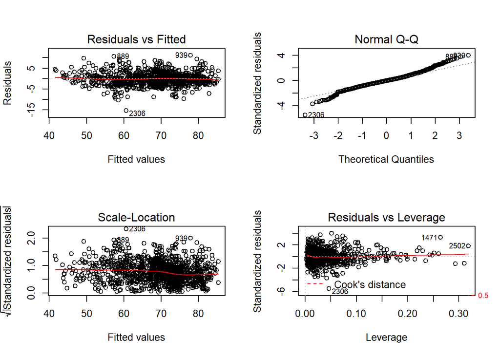

```r
par(mfrow=c(2,2))
plot(model_selected_interactions_bic)
```

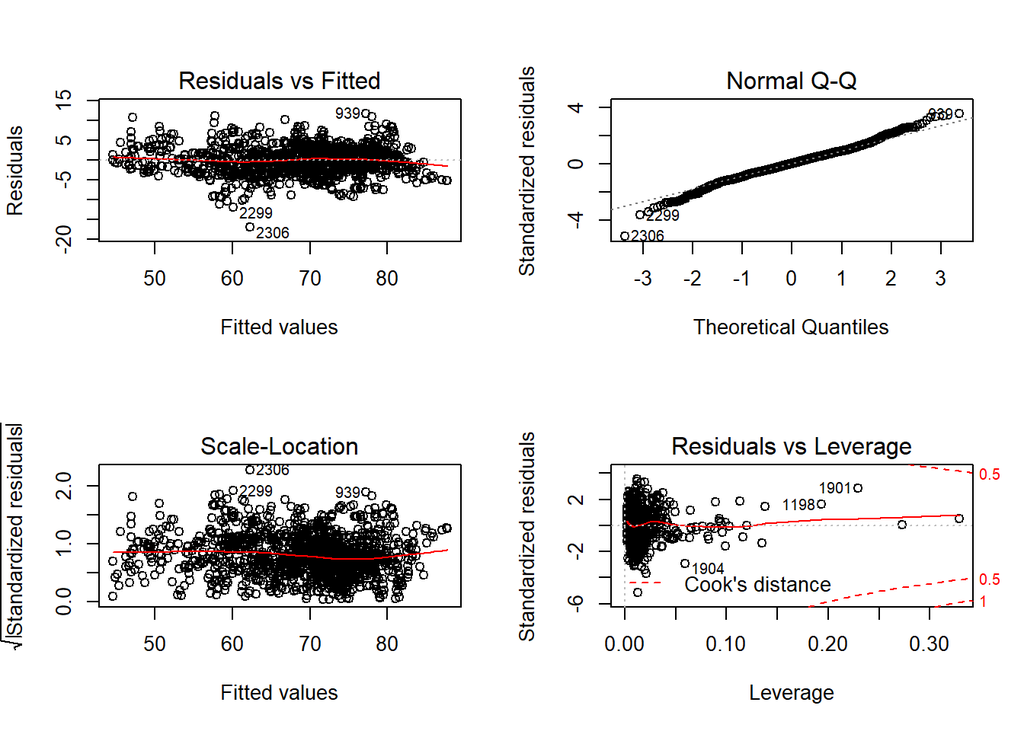

```r
model_selected_poly_interactions=lm(Life.expectancy ~ Year + Status + Adult.Mortality + infant.deaths + Alcohol + percentage.expenditure + BMI   + Polio + Total.expenditure + HIV.AIDS + thinness.5.9.years + Income.composition.of.resources + Schooling + infant.deaths:Polio +  Adult.Mortality:HIV.AIDS + I(HIV.AIDS^2) , data=train_dataset)
par(mfrow=c(2,2))
plot(model_selected_poly_interactions)
```

```r
show_metrics(model_selected_poly_interactions)
```

```
##                bptest         shapiro_test           adj_r2            LOOCV
## 1 1.9677190897313e-12 5.75490773747497e-08 0.85575066923808 3.35994204373411
##               RMSE
## 1 13.0647235669756
```

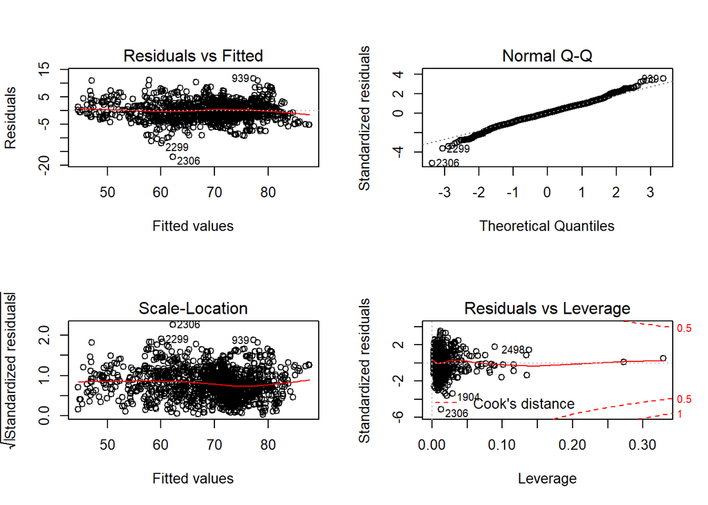

```r
model_selected_poly_interactions=lm(Life.expectancy ~ Year + Status + Adult.Mortality + infant.deaths + Alcohol + percentage.expenditure + BMI   + Polio + Total.expenditure + HIV.AIDS + thinness.5.9.years + Income.composition.of.resources + Schooling + Adult.Mortality:HIV.AIDS +I(HIV.AIDS^2) , data=train_dataset)
par(mfrow=c(2,2))
plot(model_selected_poly_interactions)
```

```r
show_metrics(model_selected_poly_interactions)
```

```
##                 bptest         shapiro_test            adj_r2            LOOCV
## 1 3.39714773015171e-11 8.52658675042634e-08 0.855014579746375 3.36156223907932
##               RMSE
## 1 13.0079077049791
```

```r
vif_poly=car::vif(model_selected_poly_interactions)
vif_poly[vif_poly > 5]
```

```
##                 HIV.AIDS            I(HIV.AIDS^2) Adult.Mortality:HIV.AIDS
##                   13.277                    9.502                    6.410
```

```r
length(coef(model_selected_poly_interactions))
```

```
## [1] 16
```

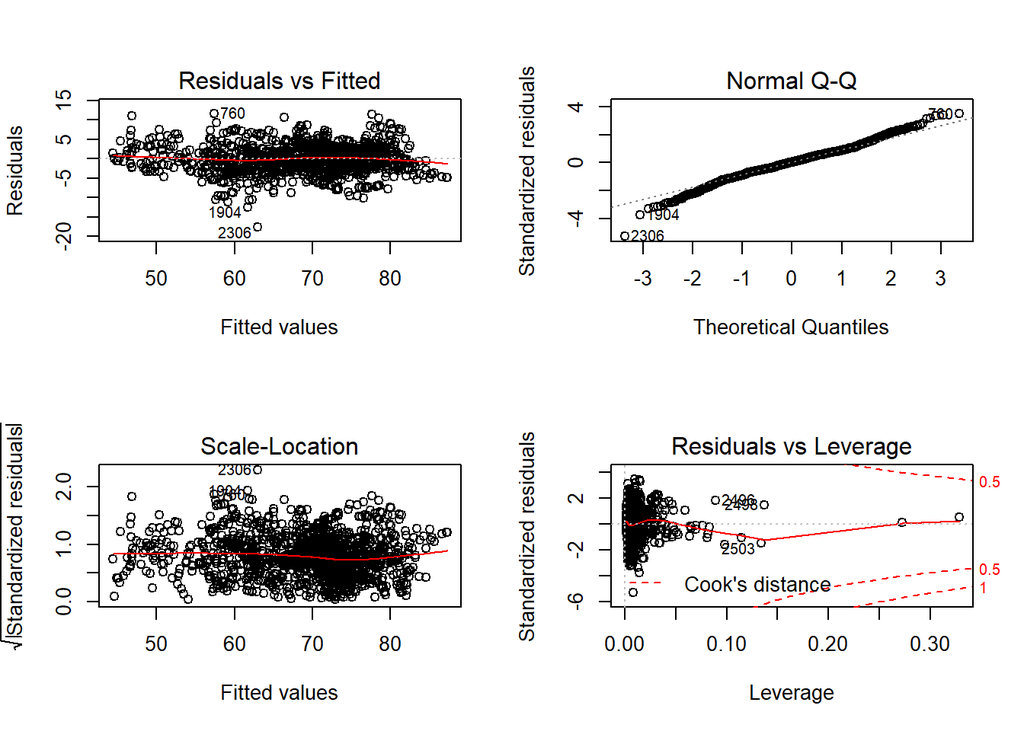

```r
model_selected_poly_interactions=lm(Life.expectancy ~ Year + Status + Adult.Mortality + infant.deaths + Alcohol + percentage.expenditure + BMI   + Polio + Total.expenditure + HIV.AIDS + thinness.5.9.years + Income.composition.of.resources + Schooling + Adult.Mortality:HIV.AIDS +I(HIV.AIDS^2) , data=train_dataset)
model_selected_poly_interactions_aic=step(model_selected_poly_interactions, trace=0, k=log(nrow(data)))
par(mfrow=c(2,2))
plot(model_selected_poly_interactions_aic)
```

```r
show_metrics(model_selected_poly_interactions_aic)
```

```
##                 bptest         shapiro_test            adj_r2            LOOCV
## 1 3.22148451037804e-07 2.52539200117266e-09 0.853326537920673 3.37489589224048
##               RMSE
## 1 13.1858663919188
```

```r
vif_poly=car::vif(model_selected_poly_interactions_aic)
vif_poly[vif_poly > 5]
```

```
##                 HIV.AIDS            I(HIV.AIDS^2) Adult.Mortality:HIV.AIDS
##                    12.71                     9.34                     6.26
```

```r
length(coef(model_selected_poly_interactions_aic))
```

```
## [1] 12
```

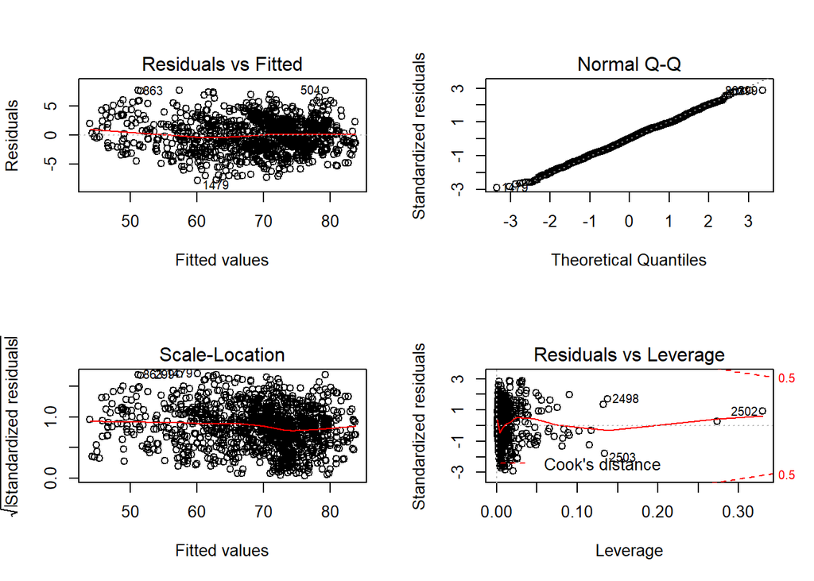

```r
model_selected_outliers=lm(formula = Life.expectancy ~  Adult.Mortality  +
    infant.deaths + Polio + HIV.AIDS + thinness.5.9.years + Income.composition.of.resources +
    Schooling  + Adult.Mortality:HIV.AIDS + I(HIV.AIDS^2), data = train_dataset, subset=abs(rstandard(model_selected_poly_interactions_aic))<2)

par(mfrow=c(2,2))
plot(model_selected_outliers)
```

```r
#show_metrics(model_selected_outliers)
#length(coef(model_selected_outliers))
```

Based on above plots, we can say that we have achieved a good model based with `10` predictors and the formula is:

`formula = Life.expectancy ~ Adult.Mortality + infant.deaths + Polio + HIV.AIDS + thinness.5.9.years + Income.composition.of.resources + Schooling + Adult.Mortality:HIV.AIDS + I(HIV.AIDS^2)`

Evaluation metric are as follows:

```r
show_metrics(model_selected_outliers)
```

```
##                 bptest      shapiro_test            adj_r2            LOOCV
## 1 1.10102872620561e-18 0.131988452361684 0.899122391497238 2.71858885362903
##               RMSE
## 1 14.1070548168968
```